# Lab3

Neha Maddali

9/28/2021

```r
#install.packages('readxl')
library(ggplot2)
library(tidyverse)
library(dplyr)
getwd()
```

```
## [1] "C:/Users/neham/Desktop/DS202/ds202_lab3"
```

```r
dat <- readxl::read_xls('./GSS.xls')
dat <- dat%>%
  rename(year = 'Gss year for this respondent', happiness = 'General happiness', partyid = 'Political party affiliation', income = 'Total family income', sex = 'Respondents sex', educ = 'Highest year of school completed', age = 'Age of respondent', marital = 'Marital status', id = 'Respondent id number', ballot = 'Ballot used for interview')
dat$educ <- suppressWarnings(as.numeric(dat$educ))
dat$age <- suppressWarnings(as.numeric(dat$age))
```

## Question 1

1. Find the average years of education for the respondents with each marital status. Arrange your output in a meaningful order and print. Describe any patterns you find.

```r
dat%>%
  select(marital, educ)%>%
  filter(educ<21)%>%
  group_by(marital)%>%
  summarise(educ_mean = mean(educ), .groups='drop')
```

```
## # A tibble: 6 x 2
##   marital       educ_mean
##   <chr>             <dbl>
## 1 Divorced           13.1
## 2 Married            13.0
## 3 Never married      13.4
## 4 No answer          15.5
## 5 Separated          11.9
## 6 Widowed            11.2
```

**My analysis** We can see for all types of marital status, the average years of education range between approximately 11 to 15. The marital status with the highest average years is the “no answer” status. The marital status with the lowest average years of education is “widowed”

## Question 2

Create a single data frame containing records for the better educated respondents with each marital status. A “better educated” respondent is someone who has strictly more years of education than the average among those with the same marital status. Print the structure of the data frame.

```r
df <- dat%>%
  group_by(marital)%>%
  filter(educ<21)%>%
  mutate(maritalMedian = median(educ))%>%
  filter(educ > maritalMedian)%>%
  select(-maritalMedian)%>%
  ungroup()
str(df)
```

```
## tibble [28,261 x 10] (S3: tbl_df/tbl/data.frame)
##  $ year     : num [1:28261] 1972 1972 1972 1972 1972 ...
##  $ happiness: chr [1:28261] "Not too happy" "Not too happy" "Pretty happy" "Not too happy" ...
##  $ partyid  : chr [1:28261] "Ind,near dem" "Not str democrat" "Ind,near dem" "Ind,near dem" ...
##  $ income   : chr [1:28261] "Not applicable" "Not applicable" "Not applicable" "Not applicable" ...
##  $ sex      : chr [1:28261] "Female" "Female" "Male" "Male" ...
##  $ educ     : num [1:28261] 16 17 14 16 13 14 14 17 14 13 ...
##  $ age      : num [1:28261] 23 27 26 27 30 54 24 46 21 21 ...
##  $ marital  : chr [1:28261] "Never married" "Married" "Never married" "Never married" ...
##  $ id       : num [1:28261] 1 4 6 8 11 16 17 19 20 23 ...
##  $ ballot   : chr [1:28261] "Not applicable" "Not applicable" "Not applicable" "Not applicable" ...
```

## Question 3

How is the happiness of a respondent related to his/her marriage status? Define that a person is happy if the response to question is “Very happy” or “Pretty happy”.

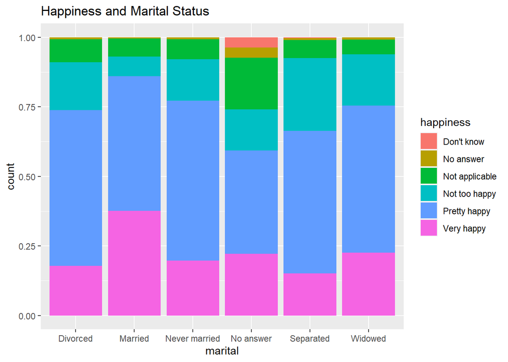

```r
dat%>%
  select(happiness, marital)%>%
  ggplot(aes(x=marital, fill=happiness)) + geom_bar(position='fill') + ggtitle("Happiness and Marital Status")
```

```r
dat%>%
  select(happiness, marital)%>%
  group_by(marital)%>%
  count(happiness)
```

```
## # A tibble: 36 x 3
## # Groups:   marital [6]
##    marital  happiness          n
##    <chr>    <chr>          <int>
##  1 Divorced Don't know         3
##  2 Divorced No answer         58
##  3 Divorced Not applicable   688
##  4 Divorced Not too happy   1450
##  5 Divorced Pretty happy    4683
##  6 Divorced Very happy      1497
##  7 Married  Don't know        12
##  8 Married  No answer        123
##  9 Married  Not applicable  2221
## 10 Married  Not too happy   2431
## # ... with 26 more rows
```

**My analysis** From the plot, we can see that “married” has the most happy respondents. The group with the least amount of happy people are those who did not answer. However, if we disregard the “no answer” category, the group with the least amount of happy people are those who are separated.

## Question 4

Does party affiliation affect the relationship you found in the last question?

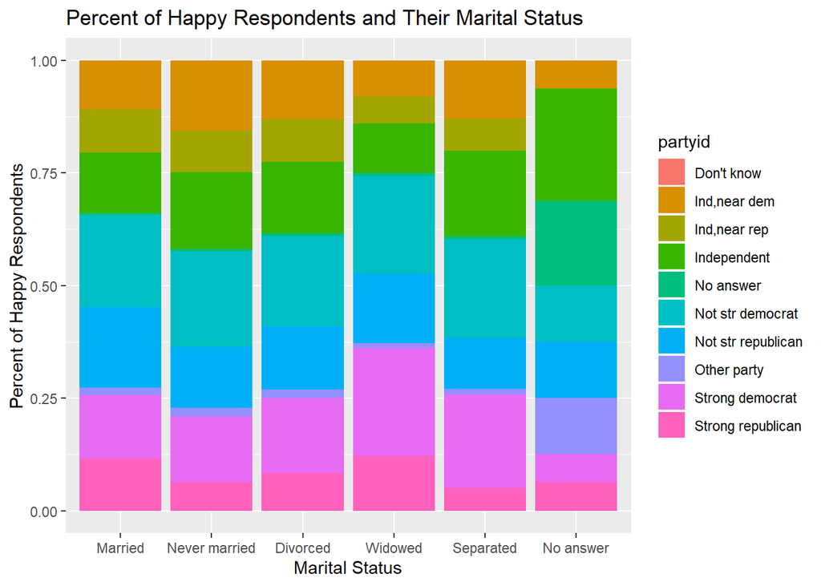

```r
happy<-filter(dat, happiness %in% c('Very happy','Pretty happy'))
happy$marital<-factor(happy$marital, levels=(c("Married","Never married","Divorced","Widowed","Separated","No answer")))
hapState<-filter(dat, happiness %in% c('Not too happy','Very happy','Pretty happy'))
hapState$marital<-factor(hapState$marital, levels=(c("Married","Never married","Divorced","Widowed","Separated","No answer")))
ggplot(happy, aes(x=marital, fill=partyid))+geom_bar(position='fill')+ggtitle("Percent of Happy Respondents and Their Marital Status")+xlab("Marital Status")+ylab("Percent of Happy Respondents")
```

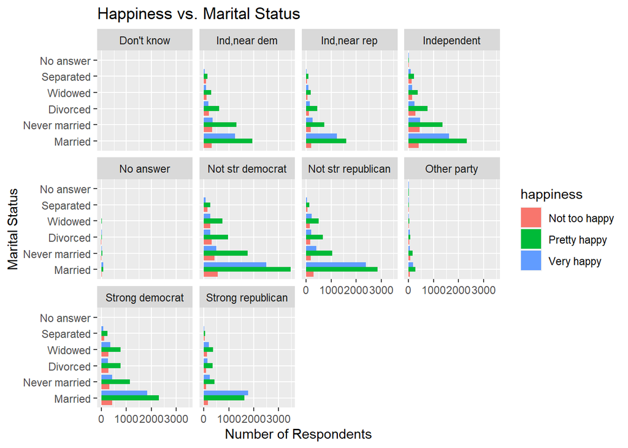

```r
ggplot(hapState, aes(x=marital, fill=happiness))+geom_bar(position='dodge')+facet_wrap(~partyid)+ggtitle("Happiness vs. Marital Status")+xlab('Marital Status')+ylab('Number of Respondents')+coord_flip()
```

```r
dat%>%
  select(happiness, marital, partyid)%>%
  group_by(marital, partyid)%>%
  count(happiness)
```

```
## # A tibble: 271 x 4
## # Groups:   marital, partyid [58]
##    marital  partyid      happiness          n
##    <chr>    <chr>        <chr>          <int>
##  1 Divorced Ind,near dem No answer          3
##  2 Divorced Ind,near dem Not applicable    74
##  3 Divorced Ind,near dem Not too happy    200
##  4 Divorced Ind,near dem Pretty happy     625
##  5 Divorced Ind,near dem Very happy       178
##  6 Divorced Ind,near rep No answer          6
##  7 Divorced Ind,near rep Not applicable    55
##  8 Divorced Ind,near rep Not too happy    106
##  9 Divorced Ind,near rep Pretty happy     435
## 10 Divorced Ind,near rep Very happy       154
## # ... with 261 more rows
```

**My analysis** The first plot below displays data only from respondents who said they were “very happy” or “pretty happy”. This allows us to see if people of a certain political party tend to be happier. From the graph, it does not appear that Political Party Affiliation has much of an effect on the relationship between marital status and happiness. There is a fairly even spread of all the political party affiliations within each column of Marital Status. Meaning there are republicans, democrats, and independents in every column. The second plot below displays a graph for each political party. In addition, it includes data from respondents who said they were “not too happy”. This plot shows similar trends for each political party. The one exception being for Strong Republican bar chart. In this chart, The number of very happy people outweigh the number of pretty happy people who are also married. In general, political party affiliation does not affect the relationship between marital status and happiness. For this I used variables happiness, marital, and partyid.

## Question 5

How is marital status related to the education of a respondent? What are possible reasons accounting for the patterns you see?

```r
levels(dat$marital)
```

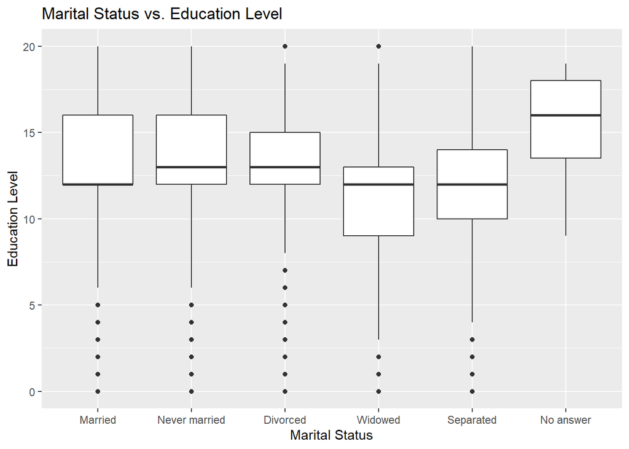

```r
dat$marital<-factor(dat$marital, levels=(c("Married","Never married","Divorced","Widowed","Separated","No answer")))
ggplot(dat, aes(x=marital, y=educ))+geom_boxplot()+ggtitle("Marital Status vs. Education Level")+xlab('Marital Status')+ylab('Education Level')
```

```r
AvgEduInMar<-dat%>%
  group_by(marital)%>%
  summarize(mean_education=mean(educ,na.rm=TRUE))%>%
  arrange(mean_education)
AvgEduInMar
```

```
## # A tibble: 6 x 2
##   marital       mean_education
##   <fct>                  <dbl>
## 1 Widowed                 11.2
## 2 Separated               11.9
## 3 Married                 13.0
## 4 Divorced                13.1
## 5 Never married           13.4
## 6 No answer               15.5
```

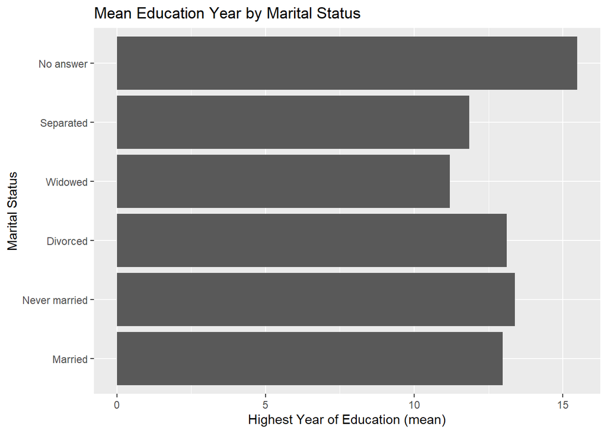

```r
ggplot(AvgEduInMar, aes(x=marital, weight=mean_education))+geom_bar()+coord_flip()+ggtitle("Mean Education Year by Marital Status")+ylab("Highest Year of Education (mean)") +xlab("Marital Status")
```

```r
dat%>%
  select(marital, educ)%>%
  group_by(marital)%>%
  count(educ)
```

```
## # A tibble: 119 x 3
## # Groups:   marital [6]
##    marital  educ     n
##    <fct>   <dbl> <int>
##  1 Married     0    67
##  2 Married     1    25
##  3 Married     2    75
##  4 Married     3   123
##  5 Married     4   149
##  6 Married     5   193
##  7 Married     6   437
##  8 Married     7   483
##  9 Married     8  1398
## 10 Married     9  1050
## # ... with 109 more rows
```